# IODS course project

Santeri Rouhinen

# Chapter 5. Dimensionality reduction techniques

## Load necessary libraries

```r
# Load required libraries
library(ggplot2)
library(dplyr)
library(corrplot)
library(GGally)
library(tidyr)
```

## 1. Load human data

```r
human <- read.csv("data/human.csv", header = TRUE, row.names = 1)

# Look at the data
str(human)
```

```
## 'data.frame':    155 obs. of  7 variables:
##  $ eduFemDivM     : num  1.007 0.997 0.983 0.989 0.969 ...
##  $ labFemDivM     : num  0.891 0.819 0.825 0.884 0.829 ...
##  $ educExpect     : num  17.5 20.2 15.8 18.7 17.9 16.5 18.6 16.5 15.9 19.2 ...
##  $ lifeExpect     : num  81.6 82.4 83 80.2 81.6 80.9 80.9 79.1 82 81.8 ...
##  $ grossIncome    : int  64992 42261 56431 44025 45435 43919 39568 52947 42155 32689 ...
##  $ motherMortality: int  4 6 6 5 6 7 9 28 11 8 ...
##  $ womenParliament: num  39.6 30.5 28.5 38 36.9 36.9 19.9 19.4 28.2 31.4 ...
```

```r
dim(human)
```

```
## [1] 155   7
```

eduFemDivM: Ratio of females to males educated at secondary and higher education levels

labFemDivM: Ratio of females to males labour market participation rate (LFPR)

educExpect: Expected years of schooling

lifeExpect: Life expectancy at birth (years)

grossIncome: Gross national income per capita (GNI)

motherMortality: Maternal mortality ratio (MMR) (deaths per 100 000 live births)

womenParliament: Share of parliamentary seats held by women (% of seats)

Further information can be found in http://hdr.undp.org/en/content/human-development-index-hdi

## 2. Graphical overview of the data.

Show summaries.

```r
summary(human)
```

```
##    eduFemDivM       labFemDivM       educExpect      lifeExpect
##  Min.   :0.1717   Min.   :0.1857   Min.   : 5.40   Min.   :49.00
##  1st Qu.:0.7264   1st Qu.:0.5984   1st Qu.:11.25   1st Qu.:66.30
##  Median :0.9375   Median :0.7535   Median :13.50   Median :74.20
##  Mean   :0.8529   Mean   :0.7074   Mean   :13.18   Mean   :71.65
##  3rd Qu.:0.9968   3rd Qu.:0.8535   3rd Qu.:15.20   3rd Qu.:77.25
##  Max.   :1.4967   Max.   :1.0380   Max.   :20.20   Max.   :83.50
##   grossIncome     motherMortality  womenParliament
##  Min.   :   581   Min.   :   1.0   Min.   : 0.00
##  1st Qu.:  4198   1st Qu.:  11.5   1st Qu.:12.40
##  Median : 12040   Median :  49.0   Median :19.30
##  Mean   : 17628   Mean   : 149.1   Mean   :20.91
##  3rd Qu.: 24512   3rd Qu.: 190.0   3rd Qu.:27.95
##  Max.   :123124   Max.   :1100.0   Max.   :57.50
```

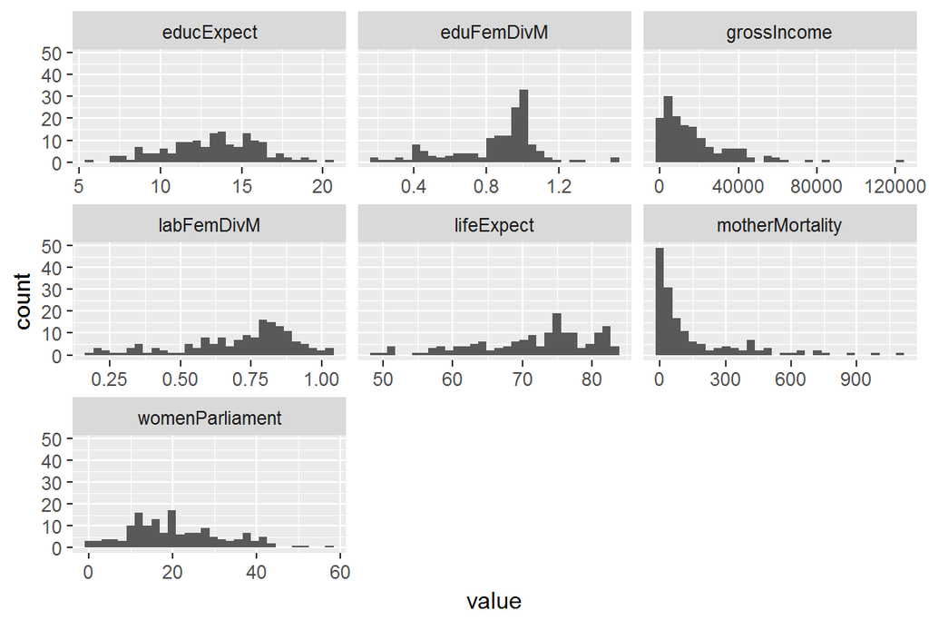

```r
# Histograms of the variables
human %>%
  gather(key=var_name, value = value) %>%
  ggplot(aes(x=value)) +
  geom_histogram() +
  facet_wrap(~var_name, scales = "free_x")
```

```r
# Correlations of the variables.
# Create color ramp from dull dark blue to white to dull red.
colorVector <- c("#4477AA", "#77AADD", "#FFFFFF", "#EE9988", "#BB4444")

# Print the correlation matrix
corMatrix<-cor(human)
corMatrix %>% round(digits = 2)
```

```
##                 eduFemDivM labFemDivM educExpect lifeExpect grossIncome
## eduFemDivM            1.00       0.01       0.59       0.58        0.43
## labFemDivM            0.01       1.00       0.05      -0.14       -0.02
## educExpect            0.59       0.05       1.00       0.79        0.62
## lifeExpect            0.58      -0.14       0.79       1.00        0.63
## grossIncome           0.43      -0.02       0.62       0.63        1.00
## motherMortality      -0.66       0.24      -0.74      -0.86       -0.50
## womenParliament       0.08       0.25       0.21       0.17        0.09
##                 motherMortality womenParliament
## eduFemDivM                -0.66            0.08
## labFemDivM                 0.24            0.25
## educExpect                -0.74            0.21
## lifeExpect                -0.86            0.17
## grossIncome               -0.50            0.09
## motherMortality            1.00           -0.09
## womenParliament           -0.09            1.00
```

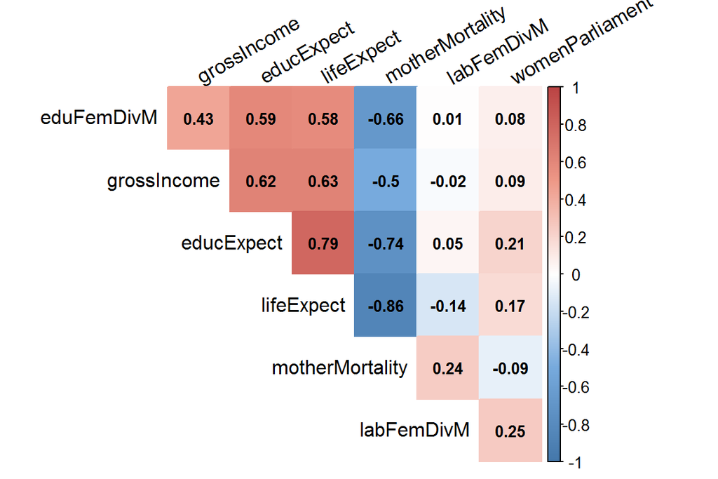

```r
# Visualize the correlation matrix


corrplot(corMatrix, method = "color", col = colorRampPalette(colorVector)(200),
         type = "upper", order = "hclust", number.cex = .8,
         addCoef.col = "black", # Add coefficient of correlation
         tl.col = "black", tl.srt = 30, # Text label color and rotation
         # Combine with significance
         #p.mat = p.mat, sig.level = 0.01, insig = "blank",
         # hide correlation coefficient on the principal diagonal
         diag = FALSE)
```

The highest positive correlations were between education expectancy and life expectancy. GNI, education expectation, and life expectancy all had quite strong positive correlations to each other. Maternal mortality was strongly negatively correlated with life expectancy, education expectancy and ratio of female to male education. The variables women in parliament and ratio of women in labour force had low correlations to other variables.

## 3. Perform PCA on non-standardized human data.

Examine the results.

```r
# perform principal component analysis (with the SVD method)
pcaHuman <- prcomp(human)

# print out a summary of PCA. One gets quite a few warnings. The first component explains a whopping 99.99 % of the variance.
s <- summary(pcaHuman)
s
```

```
## Importance of components:
##                              PC1      PC2   PC3   PC4   PC5    PC6    PC7
## Standard deviation     1.854e+04 184.0810 11.46 3.796 1.598 0.1912 0.1592
## Proportion of Variance 9.999e-01   0.0001  0.00 0.000 0.000 0.0000 0.0000
## Cumulative Proportion  9.999e-01   1.0000  1.00 1.000 1.000 1.0000 1.0000
```

```r
# rounded percetanges of variance captured by each PC
pca_pr <- round(100*s$importance[2, ], digits = 1)

# print out the percentages of variance
pca_pr
```

```
## PC1 PC2 PC3 PC4 PC5 PC6 PC7
## 100   0   0   0   0   0   0
```

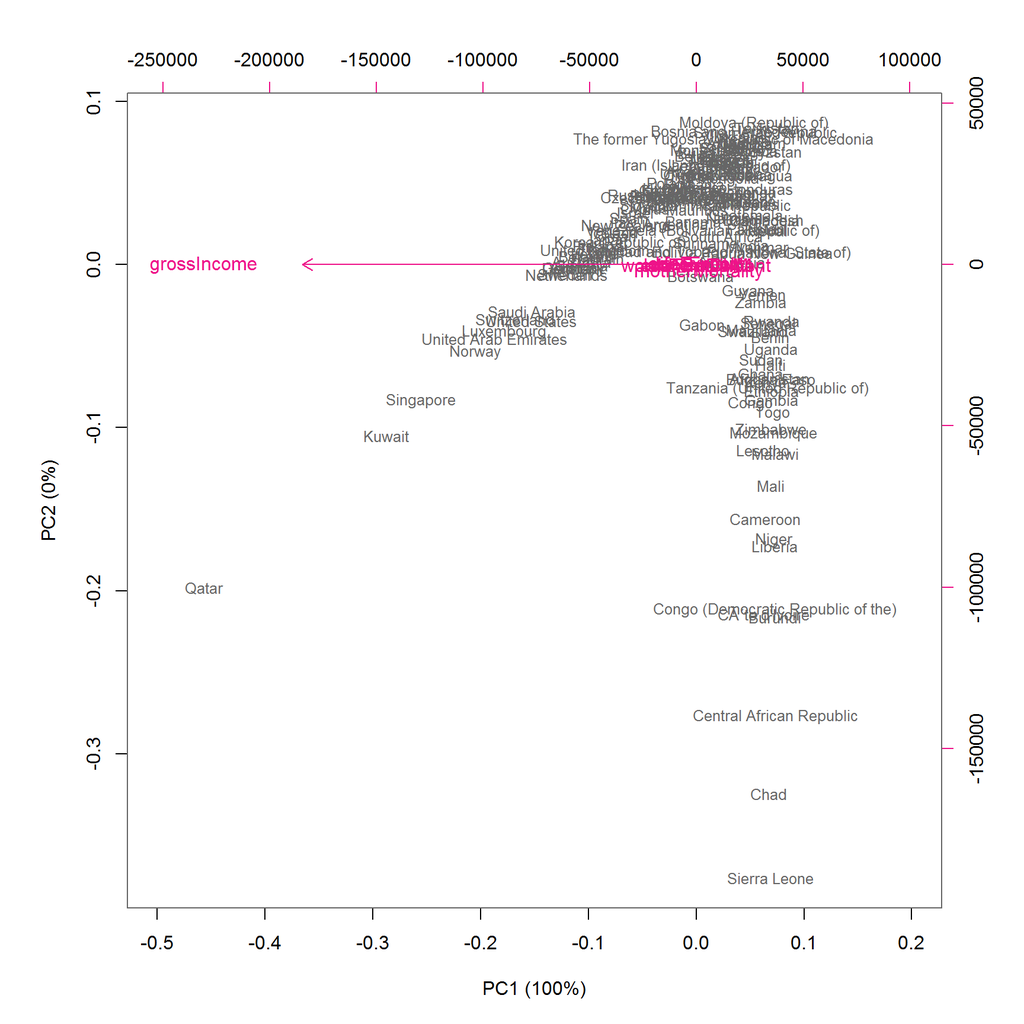

```r
# create object pc_lab to be used as axis labels
pc_lab <- paste0(names(pca_pr), " (", pca_pr, "%)")

# draw a biplot of the principal component representation and the original variables using the first 2 components. GNI explains looks to explain pretty much all of the first principal component.
biplot(pcaHuman, cex = c(0.8, 1), col = c("grey40", "deeppink2"), xlab = pc_lab[1], ylab = pc_lab[2], xlim = c(-0.5, 0.2))
```